# CO2AO - Caso práctico extended OMP

Marcos Fontela, 2019

# ¿Qué necesitamos?

Datos de inicio:

- Observaciones
- Tabla de SWT
- Posibles figuras de mezcla

# Pasos a seguir:

## Carga los datos del ejemplo:

```r
# Load data ---------------------------------------------------------------

data <- read.delim("C:/Users/MFontela/Nextcloud/ULPGC/OMPGT10/INPUT_botellas.txt", na.strings="-999")
SWT <- read_excel("C:/Users/MFontela/Nextcloud/ULPGC/OMPGT10/INPUT_SWT.xlsx")
MixingFigures <- read.delim("C:/Users/MFontela/Nextcloud/ULPGC/OMPGT10/INPUT_MixingFigures.txt", header=FALSE)
names(MixingFigures) <- c("wm1", "wm2", "wm3", "wm4") #rename table
MixingFigures <- mutate(MixingFigures, wm1=as.character(wm1),wm2=as.character(wm2),wm3=as.character(wm3),wm4=as.character(wm4))

# WEIGHTS FOR W_MATRIX (MATRIX OF WEIGHTS)
W<-data.frame(Mass=100, Tpot=20, Sal=10, SiO4=2,
              NO3=3, NO=3,NO30=3,
              PO4=2, PO=2,PO40=2,
              O2=2, O20=2)


# % REDFIELD RATIOS FOR EXTENDED OMP
Redfield<-data.frame(NO3=9.3, PO4=145, Si=37, O2=-1)
```

Ya tienes cargados los **datos iniciales** (puedes ver la tabla entera haciendo scroll hacia la izquierda):

| observation | Code | St | Btl | Year | Lat | Lon | Bottom_Depth | Pres | CTDDEPTH | Tinsitu | Tpot | Sal | O2 | SiO4 | NO3 | PO4 | DIC | Alk |
| --- | --- | --- | --- | --- | --- | --- | --- | --- | --- | --- | --- | --- | --- | --- | --- | --- | --- | --- |
| 1 | 2010121 | 1 | 21 | 2010 | 38.327317 | -9.6611 | 2819 | 112.175 | 111.55 | 15.4875 | 15.47002 | 36.1575 | 190.425 | 2.45 | 6.850538 | 0.475648 | 2136.1 | 2368.9 |
| 2 | 2010120 | 1 | 20 | 2010 | 38.327317 | -9.6611 | 2819 | 136.975 | 136.25 | 15.195 | 15.173914 | 36.1475 | 189.925 | 2.4725 | 7.493038 | 0.508148 | 2146.4 | 2369.8 |
| 3 | 2010119 | 1 | 19 | 2010 | 38.327317 | -9.6611 | 2819 | 186.425 | 185.425 | 14.3025 | 14.274932 | 36.01 | 188.025 | 3.21 | 9.748038 | 0.638148 | 2146.6 | 2358.9 |
| 4 | 2010118 | 1 | 18 | 2010 | 38.3273 | -9.6611 | 2819 | 192.1 | 191 | 14.13 | 14.101821 | 35.99 | 187.9 | 3.43 | 10.000538 | 0.658148 |  |  |
| 5 | 2010117 | 1 | 17 | 2010 | 38.3273 | -9.6611 | 2819 | 236.066667 | 234.7 | 13.636667 | 13.602821 | 35.903333 | 187.766667 | 3.69 | 10.947204 | 0.721481 |  |  |
| 6 | 2010116 | 1 | 16 | 2010 | 38.3273 | -9.6611 | 2819 | 286.4 | 284.8 | 13.34 | 13.299472 | 35.86 | 186.4 | 3.91 | 11.810538 | 0.738148 | 2153.1 | 2350.5 |
| 7 | 2010115 | 1 | 15 | 2010 | 38.327317 | -9.6611 | 2819 | 419.275 | 416.65 | 12.26 | 12.203598 | 35.7625 | 175.05 | 5.6175 | 14.808038 | 0.938148 | 2165.8 | 2346.7 |
| 8 | 2010114 | 1 | 14 | 2010 | 38.327317 | -9.6611 | 2819 | 662.025 | 657.375 | 12.83 | 12.737037 | 36.285 | 171.3 | 6.1025 | 13.410538 | 0.840648 | 2190 | 2387.5 |
| 9 | 2010113 | 1 | 13 | 2010 | 38.3273 | -9.6611 | 2819 | 804.2 | 796.3 | 12.81 | 12.696542 | 36.35 | 170.8 | 6.35 | 12.910538 | 0.838148 |  |  |
| 10 | 2010112 | 1 | 12 | 2010 | 38.3273 | -9.6611 | 2819 | 949 | 940.4 | 12.66 | 12.526224 | 36.49 | 168.6 | 6.64 | 13.740538 | 0.858148 |  |  |

[output cut: 629 more lines]

Y también las propiedades tipo de las masas de agua (SWT) que, *apoyándote en bibliografía* consideras:

| ID | wm | Tpot | Sal | SiO4 | NO3 | PO4 | O2 | Alk | Ct | O20 |
| --- | --- | --- | --- | --- | --- | --- | --- | --- | --- | --- |
| 1 | AABW | 1.48 | 34.84 | 66.5 | 24.2 | 1.67 | 240 | 2352 | 2202 | 240 |
| 2 | DSOW | 1.3 | 34.905 | 8 | 10.4 | 0.7 | 315 | 2310 | 2200 | 305 |
| 3 | NADWl | 1.88 | 34.88 | 48.5 | 21.9 | 1.5 | 242 | 2349 | 2203 | 242 |
| 4 | LSW | 3 | 34.87 | 7.8 | 15.8 | 1.07 | 285 | 2301 | 2118 | 295 |
| 5 | ISOW | 2.6 | 34.98 | 9 | 15.4 | 1.09 | 280 | 2290 | 2099 | 295 |
| 6 | NADWu | 2.5 | 34.94 | 30 | 18.8 | 1.31 | 258.576245 | 2327.161974 | 2160.62188 | 258.576245 |
| 7 | MW | 11.7 | 36.5 | 7.7 | 10.3 | 0.62 | 209 | 2411 | 2151 | 209 |
| 8 | AAIW | 6.5 | 34.9 | 21.2 | 33 | 2.15 | 102 | 2315 | 2210 | 120 |
| 9 | ENACWP | 8 | 35.23 | 11 | 18 | 1.1 | 200 | 2320 | 2112 | 200 |
| 10 | H | 12.2 | 35.6 | 4.4 | 12.4 | 0.74 | 200 | 2338 | 2107 | 210 |

[output cut: 5 more lines]

También cargaste las posibles Mixing Figures:

|  | wm1 | wm2 | wm3 | wm4 |
| --- | --- | --- | --- | --- |
| 1 | NEW | SMW | STMW | H |
| 2 | AAIW | H | ENACWP | MW |
| 3 | AAIW | LSW | ENACWP | MW |
| 4 | AAIW | LSW | NADWu | MW |
| 5 | ENACWP | LSW | NADWu | MW |
| 6 | ISOW | LSW | NADWl | MW |
| 7 | ISOW | DSOW | LSW | AABW |
| 8 | AAIW | SACW | STMW | H |
| 9 | ENACW16 | H | MW | NOSWT |

## Diagrama T-S

Siempre es bonito ver los datos de botella con las SWT consideradas, ¿no crees? Además te ayuda a ver si escogiste bien las masas de agua tipo.

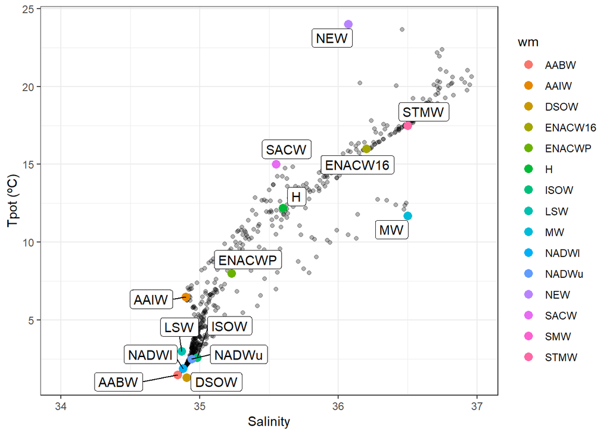

### Añade más variables

El siguiente paso es **calcular aquellos trazadores** que no estén entre los datos iniciales: NO, PO, los nutrientes preformados…

```r
# Add variables NO, PO, AOU, preformed...--------------------------------------

data<-data %>%
  mutate(NO=O2+(Redfield$NO3*NO3),
        PO=O2+(Redfield$PO4*PO4),
         AOU=(exp(-135.29996 + 157228.8/(Tpot+273.15) - 66371490/(Tpot+273.15)^2 + 12436780000/(Tpot+273.15)^3 - 862106100000/(Tpot+273.15)^4 -(Sal*(0.020573 - 12.142/(Tpot+273.15) + 2363.1/(Tpot+273.15)^2))))-O2, #la primera parte es la sw_satO2 del mítico SEAWATER toolbox del matlab. reference: "Weiss, R. F. 1970: "The solubility of nitrogen, oxygen and argon in water and seawater."Deep-Sea Research., 1970, Vol 17, pp721-735.
                 O20=O2+AOU,
        NO30=NO3-(AOU/Redfield$NO3),
        PO40=PO4-(AOU/Redfield$PO4))

SWT<-SWT %>%
  mutate(NO=O2+(Redfield$NO3*NO3),
         PO=O2+(Redfield$PO4*PO4),
         AOU=O20-O2,
         NO30=NO3-(AOU/Redfield$NO3),
         PO40=PO4-(AOU/Redfield$PO4))
```

Si vuelves a ver ahora las dos tablas, verás que hay nuevas columnas (cada vez más a la izquierda, sí…):

| observation | Code | St | Btl | Year | Lat | Lon | Bottom_Depth | Pres | CTDDEPTH | Tinsitu | Tpot | Sal | O2 | SiO4 | NO3 | PO4 | DIC | Alk | NO | PO | AOU | O20 | NO30 | PO40 |
| --- | --- | --- | --- | --- | --- | --- | --- | --- | --- | --- | --- | --- | --- | --- | --- | --- | --- | --- | --- | --- | --- | --- | --- | --- |
| 1 | 2010121 | 1 | 21 | 2010 | 38.327317 | -9.6611 | 2819 | 112.175 | 111.55 | 15.4875 | 15.47002 | 36.1575 | 190.425 | 2.45 | 6.850538 | 0.475648 | 2136.1 | 2368.9 | 254.1350034 | 259.39396 | 53.1338876630358 | 243.558887663036 | 1.13721674591013 | 0.109207395427339 |
| 2 | 2010120 | 1 | 20 | 2010 | 38.327317 | -9.6611 | 2819 | 136.975 | 136.25 | 15.195 | 15.173914 | 36.1475 | 189.925 | 2.4725 | 7.493038 | 0.508148 | 2146.4 | 2369.8 | 259.6102534 | 263.60646 | 55.0587584841595 | 244.983758484159 | 1.57274138880006 | 0.128432424247176 |
| 3 | 2010119 | 1 | 19 | 2010 | 38.327317 | -9.6611 | 2819 | 186.425 | 185.425 | 14.3025 | 14.274932 | 36.01 | 188.025 | 3.21 | 9.748038 | 0.638148 | 2146.6 | 2358.9 | 278.6817534 | 280.55646 | 61.5682752640898 | 249.59327526409 | 3.12779334794734 | 0.213539205075243 |
| 4 | 2010118 | 1 | 18 | 2010 | 38.3273 | -9.6611 | 2819 | 192.1 | 191 | 14.13 | 14.101821 | 35.99 | 187.9 | 3.43 | 10.000538 | 0.658148 |  |  | 280.9050034 | 283.33146 | 62.5880980530393 | 250.488098053039 | 3.27063498354416 | 0.226505944461798 |
| 5 | 2010117 | 1 | 17 | 2010 | 38.3273 | -9.6611 | 2819 | 236.066667 | 234.7 | 13.636667 | 13.602821 | 35.903333 | 187.766667 | 3.69 | 10.947204 | 0.721481 |  |  | 289.5756642 | 292.381412 | 65.3856711699402 | 253.15233816994 | 3.91648666989891 | 0.270545336759033 |
| 6 | 2010116 | 1 | 16 | 2010 | 38.3273 | -9.6611 | 2819 | 286.4 | 284.8 | 13.34 | 13.299472 | 35.86 | 186.4 | 3.91 | 11.810538 | 0.738148 | 2153.1 | 2350.5 | 296.2380034 | 293.43146 | 68.3809233394912 | 254.780923339491 | 4.45775054414073 | 0.266555425244888 |
| 7 | 2010115 | 1 | 15 | 2010 | 38.327317 | -9.6611 | 2819 | 419.275 | 416.65 | 12.26 | 12.203598 | 35.7625 | 175.05 | 5.6175 | 14.808038 | 0.938148 | 2165.8 | 2346.7 | 312.7647534 | 311.08146 | 85.6702992063618 | 260.720299206362 | 5.59617787028367 | 0.347318350300953 |
| 8 | 2010114 | 1 | 14 | 2010 | 38.327317 | -9.6611 | 2819 | 662.025 | 657.375 | 12.83 | 12.737037 | 36.285 | 171.3 | 6.1025 | 13.410538 | 0.840648 | 2190 | 2387.5 | 296.0180034 | 293.19396 | 85.6397514919855 | 256.939751491985 | 4.20196257075425 | 0.250029024193204 |
| 9 | 2010113 | 1 | 13 | 2010 | 38.3273 | -9.6611 | 2819 | 804.2 | 796.3 | 12.81 | 12.696542 | 36.35 | 170.8 | 6.35 | 12.910538 | 0.838148 |  |  | 290.8680034 | 292.33146 | 86.2347433499999 | 257.03474335 | 3.63798495161292 | 0.243425632068967 |
| 10 | 2010112 | 1 | 12 | 2010 | 38.3273 | -9.6611 | 2819 | 949 | 940.4 | 12.66 | 12.526224 | 36.49 | 168.6 | 6.64 | 13.740538 | 0.858148 |  |  | 296.3870034 | 293.03146 | 89.0769433421019 | 257.676943342102 | 4.16237204923635 | 0.24382425281309 |

[output cut: 629 more lines]

Y también en la tabla de las SWT:

| ID | wm | Tpot | Sal | SiO4 | NO3 | PO4 | O2 | Alk | Ct | O20 | NO | PO | AOU | NO30 | PO40 |
| --- | --- | --- | --- | --- | --- | --- | --- | --- | --- | --- | --- | --- | --- | --- | --- |
| 1 | AABW | 1.48 | 34.84 | 66.5 | 24.2 | 1.67 | 240 | 2352 | 2202 | 240 | 465.06 | 482.15 | 0 | 24.2 | 1.67 |
| 2 | DSOW | 1.3 | 34.905 | 8 | 10.4 | 0.7 | 315 | 2310 | 2200 | 305 | 411.72 | 416.5 | -10 | 11.4752688172043 | 0.768965517241379 |
| 3 | NADWl | 1.88 | 34.88 | 48.5 | 21.9 | 1.5 | 242 | 2349 | 2203 | 242 | 445.67 | 459.5 | 0 | 21.9 | 1.5 |
| 4 | LSW | 3 | 34.87 | 7.8 | 15.8 | 1.07 | 285 | 2301 | 2118 | 295 | 431.94 | 440.15 | 10 | 14.7247311827957 | 1.00103448275862 |
| 5 | ISOW | 2.6 | 34.98 | 9 | 15.4 | 1.09 | 280 | 2290 | 2099 | 295 | 423.22 | 438.05 | 15 | 13.7870967741935 | 0.986551724137931 |
| 6 | NADWu | 2.5 | 34.94 | 30 | 18.8 | 1.31 | 258.576245 | 2327.161974 | 2160.62188 | 258.576245 | 433.416245 | 448.526245 | 0 | 18.8 | 1.31 |
| 7 | MW | 11.7 | 36.5 | 7.7 | 10.3 | 0.62 | 209 | 2411 | 2151 | 209 | 304.79 | 298.9 | 0 | 10.3 | 0.62 |
| 8 | AAIW | 6.5 | 34.9 | 21.2 | 33 | 2.15 | 102 | 2315 | 2210 | 120 | 408.9 | 413.75 | 18 | 31.0645161290323 | 2.02586206896552 |
| 9 | ENACWP | 8 | 35.23 | 11 | 18 | 1.1 | 200 | 2320 | 2112 | 200 | 367.4 | 359.5 | 0 | 18 | 1.1 |
| 10 | H | 12.2 | 35.6 | 4.4 | 12.4 | 0.74 | 200 | 2338 | 2107 | 210 | 315.32 | 307.3 | 10 | 11.3247311827957 | 0.671034482758621 |

[output cut: 5 more lines]

## Escogemos una observación

Asegúrate que eliminaste los datos de superficie a 100 metros, que no entran en el análisis. En nuestro caso la menor profundidad que existe en los datos es ya 100.3m, por lo tanto podemos seguir.

Lo siguiente fue **definir una muestra concreta**, en este ejemplo vamos a caracterizar la composición de masas de agua de la **muestra 200.** La muestra seleccionada tiene esta composición:

|  | Tpot | Sal | SiO4 | NO | PO |
| --- | --- | --- | --- | --- | --- |
| 200 | 3.129 | 34.96 | 28.8 | 429.172 | 440.881 |

Vamos a comprobar que proporción de masas de agua componen esa muestra concreta. Empezamos encontrando cuál es la figura de mezcla que mejor explica la composición de esta muestra concreta a través de un OMP clasico (de ahí la *‘c’* de *‘cOMP’* y del nombre del resto de las variables:). Recuerda: **clásico** hace referencia a que únicamente considera **variables conservativas**: Temperatura potencial, salinidad, el macronutriente silicato (asumido conservativo) y los trazadores NO & PO.

Empezamos por la posibilidad de mezcla 1:

```r
sample<-data[observation,]
sample<- sample %>%
  select("Tpot", "Sal", "SiO4", "NO", "PO")
# preparas matriz de pesos
W_matrixSel<-W%>%select("Mass", "Tpot", "Sal", "SiO4", "NO", "PO")
W_matrixSel<-bind_rows(W_matrixSel,W_matrixSel,W_matrixSel,W_matrixSel)
#¿Será la mejor figura de mezcla la número 1?
FigurademezclaUNO<-MixingFigures[1,] #La primera fila
  selectedSWTc<-SWT %>%
  select("wm","Tpot", "Sal", "SiO4", "NO", "PO")%>%
    filter(wm %in% FigurademezclaUNO)%>%
    arrange(factor(wm, levels = unlist(FigurademezclaUNO)))%>% #Para que la tabla conserve el mismo orden que en el archivo MixingFigures original
    select(-"wm") #Deseleccionas las masas de agua por comodidad
  #Calcula el valor medio de esas masas de agua:
  meanselectedSWTc<-selectedSWTc%>% mutate_all(funs(mean))
  #y calculas la desviación estándar
  stdselectedSWTc<-selectedSWTc%>%  mutate_all(funs(sd))

  #Normalizas! #normalizas la Mixing figure y le añades una columna de unos (NOTA: normalizar un valor X es restarle la media y dividir el resultado por la std)
  normSWTc<-as.data.frame(c(1,(selectedSWTc-meanselectedSWTc)/stdselectedSWTc)) #y añades un uno (la masa, NO TOCAR)
  # y ponderas por peso:
  wnormSWTc<-normSWTc* W_matrixSel

  #Repites el proceso para la sample (normalizar y ponderar por peso)
  normsample<-as.data.frame(c(1,(sample-meanselectedSWTc[1,])/stdselectedSWTc[1,])) #y le pones un 1 delante (la masa)
  wnormsample<-normsample*W_matrixSel[1,]

  #la función lsqnonneg admite como entrada una matriz y un vector, los preparo:
  #¿Cómo? convirtiéndolos desde lo que son ahora a lo que pide la función.
  wnormSWTc<-t(as.matrix.data.frame(wnormSWTc)) #preparo matriz
  wnormsample<-as.vector(as.matrix.data.frame(wnormsample)) #preparo vector
  lsqnonneg(wnormSWTc,wnormsample)
```

```
## $x
## [1] 0.000000 0.000000 0.000000 1.099624
##
## $resid.norm
## [1] 1738.029
```

```r
# Interpreta la salida
```

¡Tremendo residuo.normalizado! Parece que esta figura de mezcla no es la que mejor le va, ¿no crees? Que te toca ahora… pues volver a plantear este mismo fragmento del script con la siguiente figura de mezcla… o meterlo en un **loop for** que lo haga por ti… ¡ya verás como no ye tan difícil!

[figure not shown]

## classic OMP (cOMP)

```r
# SWT classic OMP ---------------------------------------------------------
# {'Tpot'  'Sal'  'SiO4'  'NO'  'PO'}
SWTc<-SWT %>%
  select("wm","Tpot", "Sal", "SiO4", "NO", "PO")

sample<-data[observation,]
sample<- sample %>%
  select("Tpot", "Sal", "SiO4", "NO", "PO")
#-------
# preparas matriz de pesos
W_matrixSel<-W%>%select("Mass", "Tpot", "Sal", "SiO4", "NO", "PO")
W_matrixSel<-bind_rows(W_matrixSel,W_matrixSel,W_matrixSel,W_matrixSel)

cOMP<-list() #Generas una lista para guardar los datos
   for (nMF in 1:nrow(MixingFigures)) { #Aquí es dónde planteas el for loop para todas las mixing figures posibles
      selectedSWTc<-SWTc %>%
        filter(wm %in% MixingFigures[nMF,])%>%
        arrange(factor(wm, levels = unlist(MixingFigures[nMF,])))%>% #Para que la tabla conserve el mismo orden que en el archivo MixingFigures original
        select(-"wm") #Selecciona las masas de agua
            meanselectedSWTc<-selectedSWTc%>%
              mutate_all(funs(mean)) #Calcula el valor medio de esas masas de agua
            stdselectedSWTc<-selectedSWTc%>%
              mutate_all(funs(sd)) #y la desviación estándar
                  normSWTc<-as.data.frame(c(1,(selectedSWTc-meanselectedSWTc)/stdselectedSWTc))
                  #solución provisional
                  if (nMF==9) { #Porque hay 3 watermasses en vez de 4
                    wnormSWTc<-normSWTc* W_matrixSel[1:3,]
                  } else {
                    wnormSWTc<-normSWTc* W_matrixSel}#normalizas la Mixing figure y le añades una columna de unos (NOTA: normalizar un valor X es restarle la media y dividir el resultado por la std)
  #Después, normalizas la sample
  normsample<-as.data.frame(c(1,(sample-meanselectedSWTc[1,])/stdselectedSWTc[1,])) #y le pones un 1 delante (la masa)
  wnormsample<-normsample*W_matrixSel[1,] #normalizas la muestra según el peso
  #la función lsqnonneg necesita una matriz y un vector, los preparo
  wnormSWTc<-t(as.matrix.data.frame(wnormSWTc)) #preparo matriz
  wnormsample<-as.vector(as.matrix.data.frame(wnormsample)) #preparo vector
   cOMP[[nMF]]<-(lsqnonneg(wnormSWTc,wnormsample))
   }
#en realidad sólo quieres encontrar el menor residuo, que será la mejor figura posible:
resid<-c()
for (i in 1:nrow(MixingFigures)) {
    resid[i]<-(cOMP[[i]]$resid.norm)
}
bestMF=which(resid==min(resid))
```

## extended OMP (eOMP)

Una vez que con el classicOMP has decidido qué figura de mezcla es la mejor, que en este caso es la figura **número 4** (la formada por las **masas de agua AAIW, LSW, NADWu, MW**) pasas a aplicar a esa figura en concreto el extended OMP. Muy similar pero con una columna/incógnita más:

```r
sample<-data[observation,]
sample<- sample %>%
  select("Tpot", "Sal", "SiO4", "NO3", "PO4","O2")
#-------
# preparas matriz de pesos
W_matrixSel<-W%>%select("Mass", "Tpot", "Sal", "SiO4", "NO3", "PO4", "O2")
W_matrixSel<-bind_rows(W_matrixSel,W_matrixSel,W_matrixSel,W_matrixSel,W_matrixSel)

eOMP<-list()
      selectedSWTe<-SWT%>%
        select("wm","Tpot", "Sal", "SiO4", "NO30", "PO40","O20") %>%
        filter(wm %in% MixingFigures[bestMF,])%>% #te quedas solo con las masas de agua que están en la mejor mixing figure
        arrange(factor(wm, levels = unlist(MixingFigures[nMF,])))%>% #Para que la tabla conserve el mismo orden que en el archivo MixingFigures original
        select(-"wm") #Deselecciona las masas de agua (por comodidad de cara los cálculos)
            meanselectedSWTe<-selectedSWTe%>%
              mutate_all(funs(mean)) #Calcula el valor medio de esas masas de agua
            stdselectedSWTe<-selectedSWTe%>%
              mutate_all(funs(sd)) #y la desviación estándar
                  normSWTe<-as.data.frame(c(1,(selectedSWTe-meanselectedSWTe)/stdselectedSWTe))
   # -------- extended: with Redfield ratios!
  Redfieldratios<-c(0, 0,Redfield$Si, Redfield$NO3, Redfield$PO4, Redfield$O2)
  columntoadd<-data.frame(X1=0, 1/(Redfieldratios*stdselectedSWTe[1,])) #el primer cero es de la masa (columna de nombre X1 por el momento)
  columntoadd[2:3]=0 #Para que te quite los Inf que salen de hacer la inversa de 0.
      normSWTe<-bind_rows(normSWTe, columntoadd) #Le añades la columna del extended
                                     wnormSWTe<-normSWTe* W_matrixSel#normalizas la Mixing figure y le añades una columna de unos
  #Después, normalizas la sample
  normsample<-as.data.frame(c(1,(sample-meanselectedSWTe[1,])/stdselectedSWTe[1,])) #y le pones un 1 delante (la masa)
  wnormsample<-normsample*W_matrixSel[1,] #normalizas la muestra según el peso


  #la función lsqnonneg necesita una matriz y un vector, los preparo
  wnormSWTe<-t(as.matrix.data.frame(wnormSWTe)) #preparo matriz
  wnormsample<-as.vector(as.matrix.data.frame(wnormsample)) #preparo vector
   eOMP<-(lsqnonneg(wnormSWTe,wnormsample))
   #Ponerle los nombres
     if (bestMF==9) { #Porque hay 3 watermasses en vez de 4 en la mixingFigure 9
    colnames<-c(paste(MixingFigures[bestMF,1:3]), "bio")
  } else {
    colnames<-c(paste(MixingFigures[bestMF,]), "bio")}
   names(eOMP$x)<-colnames
   eOMP #print the result
```

```
## $x
##        AAIW         LSW       NADWu          MW         bio
##  0.01697792  0.02773752  0.84056464  0.11471992 29.57026700
##
## $resid.norm
## [1] 0.001115317
```

# Resultado final

La composición de la muestra 200, explicada por la figura de mezcla AAIW, LSW, NADWu, MW, es:

- 1.7% de AAIW
- 2.77% de LSW
- 84.06% de NADWu
- 11.47% de MW

Ya sabes hacerlo para una muestra, así que ahora que ya eres un experto en R, que será mejor, ¿hacerlo muestra a muestra o montar un *for loop* para todas? ;)

[figure not shown]